# Optimización de hiperparámetros

Nicolás Álvarez

2023-04-27

```r
library(tensorflow)
library(keras)
library(tidyverse)
library(tidymodels)
library(patchwork)
```

# PRIMER EJEMPLO

## Preparamos los datos

Comenzamos cargando el conjunto de datos de (https://archive.ics.uci.edu/ml/datasets/auto+mpg). Nos quedamos con las variables de interés. Queremos estudiar la relación entre el peso del coche (‘weight’ en libras) y el consumo del coche (‘mpg’ en millas por galón). *weight* es la columna V5 y *mpg* es la V1 (se puede consultar en ‘auto-mpg.data’). Aprovechamos también para cambiar los datos a las unidades habituales ($kg$ y $L/100 km$)

```r
dataset<-read.table('auto-mpg.data',header=T,sep='')
datos<-dataset[,c(5,1)]
colnames(datos)<-c("Peso","Consumo")
datos[,1]<-0.4536*datos[,1]
datos[,2]<-235.215/datos[,2]

summary(datos)
```

```
##       Peso           Consumo
##  Min.   : 731.7   Min.   : 5.048
##  1st Qu.:1008.4   1st Qu.: 8.111
##  Median :1270.1   Median :10.227
##  Mean   :1346.8   Mean   :11.208
##  3rd Qu.:1637.0   3rd Qu.:13.441
##  Max.   :2331.5   Max.   :26.135
```

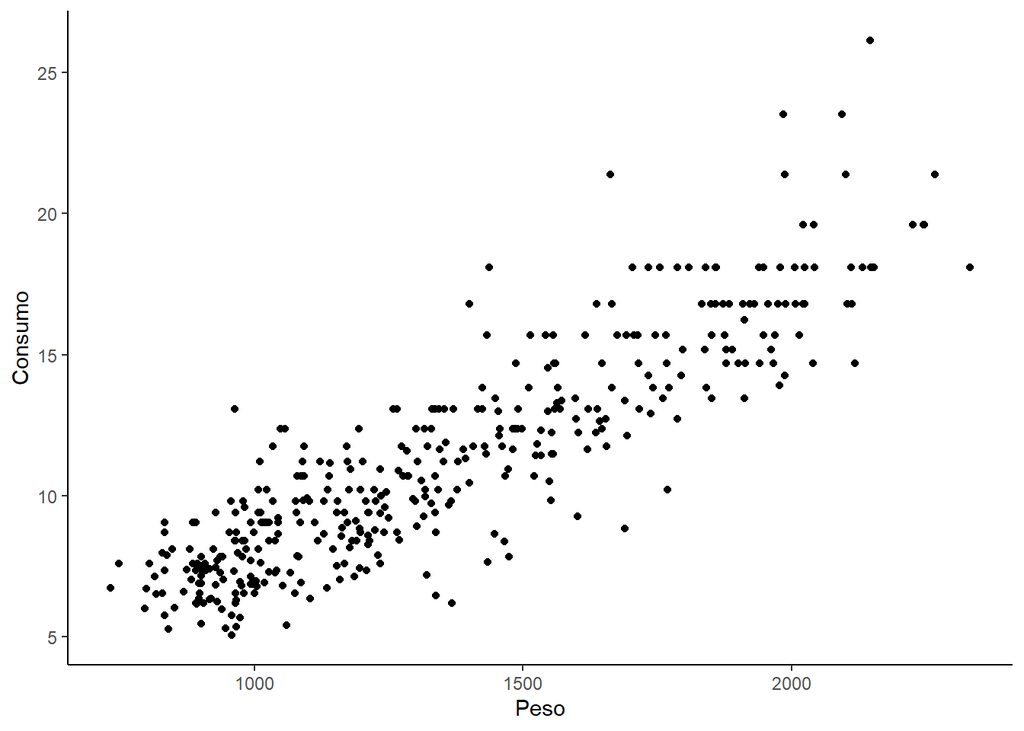

```r
ggplot() +
  geom_point(data = datos, aes(x = Peso, y = Consumo))+
  theme_classic()
```

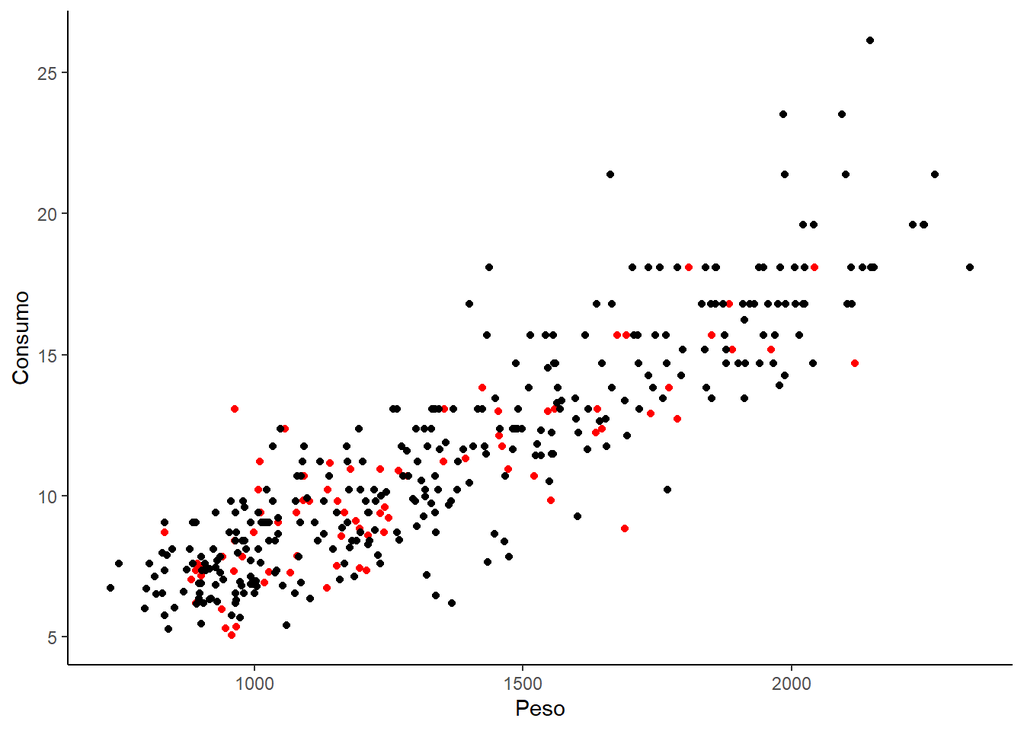

```r
split <- initial_split(datos, 0.8)
datos_train <- training(split)
datos_test <- testing(split)

ggplot() +
  geom_point(data = datos_test, aes(x = Peso, y = Consumo), color = "red") +
  geom_point(data = datos_train, aes(x = Peso, y = Consumo))+
  theme_classic()
```

## Creamos y entrenamos la Red Neuronal

Empezamos creando un modelo simple (MLP) secuencialmente, i.e., definiendo capa por capa. Comenzemos añadiendo una sola capa intermedia con 3 neuronas.

```r
normalizer <- layer_normalization(input_shape = shape(1), axis = NULL)
normalizer %>% adapt(matrix(datos_train[,1]))

modelo1 <- keras_model_sequential() %>%
  normalizer() %>%
  layer_dense(units = 3) %>%
  layer_dense(units = 1)


summary(modelo1) # Informacion general
```

```
## Model: "sequential"
## ________________________________________________________________________________
##  Layer (type)                  Output Shape               Param #    Trainable
## ================================================================================
##  normalization (Normalization)  (None, 1)                 3          Y
##  dense_1 (Dense)               (None, 3)                  6          Y
##  dense (Dense)                 (None, 1)                  4          Y
## ================================================================================
## Total params: 13
## Trainable params: 10
## Non-trainable params: 3
## ________________________________________________________________________________
```

Podemos ver que ya podemos predecir valores de la variable respuesta *Consumo* aunque son erróneos, aún no hemos entrenado nuestro modelo.

```r
predict(modelo1, datos_train[1:5,1])
```

```
##            [,1]
## [1,]  0.9271194
## [2,] -1.4299712
## [3,]  0.9674608
## [4,] -0.3734106
## [5,]  0.8646862
```

Compilamos el modelo. Utilizaremos el optimizador **adam** (*Adam is an optimization algorithm that can be used instead of the classical stochastic gradient descent procedure to update network weights iterative based in training data*)

```r
modelo1 %>% compile(
  optimizer = optimizer_adam(learning_rate = 0.1),
  loss = 'mean_absolute_error'
)
```

Finalmente, podemos pasar a entrenar el modelo con los datos de entrenamiento (*datos_train*) que hemos preparado antes. Además, aportamos los datos de validación (*datos_test*), que no se usan como tal en el entreno sino para evaluar la función de pérdida (en este caso, el error medio absoluto (ver arriba)).

Obtenemos la gráfica de pérdida (*loss*) frente a los pasos (*epoch*). También el valor de la función de pérdida en el último paso: *val_loss* es sobre los datos de validación y *loss* sobre los datos de entrenamiento.

```r
history <- modelo1 %>% fit(
  as.matrix(datos_train[,1]),
  as.matrix(datos_train[,2]),
  epochs = 100,
  verbose = 0,
  validation_data=datos_test
)

history
```

```
##
## Final epoch (plot to see history):
##     loss: 1.443
## val_loss: 1.329
```

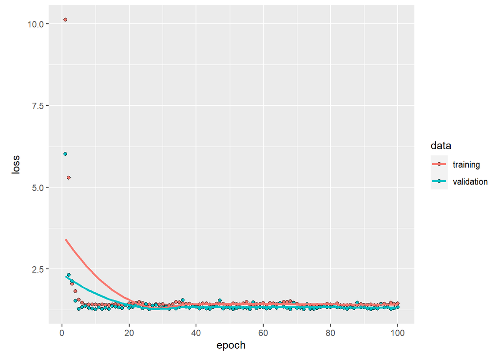

```r
plot(history)
```

## Modificando el Learning Rate

Vamos a crear una función que compile y entrene un modelo dado y que devuelva la evolución de la función de pérdida en cada paso del entrenamiento. La función **fun_entrenamiento** tiene entradas

- *modelo*: Un modelo creado con la función *keras_model_sequential()* o similar
- *lr*: Learning rate
- *npasos*: Número de pasos del entrenamiento (*epochs*)

La función devolverá un *data frame* con 3 columnas:

- Col. 1: paso
- Col. 2: *loss*, la función de pérdida evaluada en los datos de entrenamiento
- Col. 3: *val_loss*, la función de pérdida evaluada en los datos de validación cruzada

```r
fun_entrenamiento<- function(modelo,lr,npasos){
    modelo %>% compile(
        optimizer = optimizer_adam(learning_rate = lr),
        loss = 'mean_absolute_error'
      )

    foo<- modelo %>% fit(
        as.matrix(datos_train[,1]),
        as.matrix(datos_train[,2]),
        epochs = npasos,
        verbose = 0,
        validation_data=datos_test
      )

    paso<-seq(1,npasos,1)
    loss<-foo$metrics$loss
    val_loss<-foo$metrics$val_loss
    return(data.frame(paso,loss,val_loss))
}
```

Con la función hecha, vamos a tomar varios valores distintos para el LR. Por ejemplo, $lr=\{0.0001,0.001,0.01,0.1\}$. Con un número de pasos fijo de 100, obtenemos:

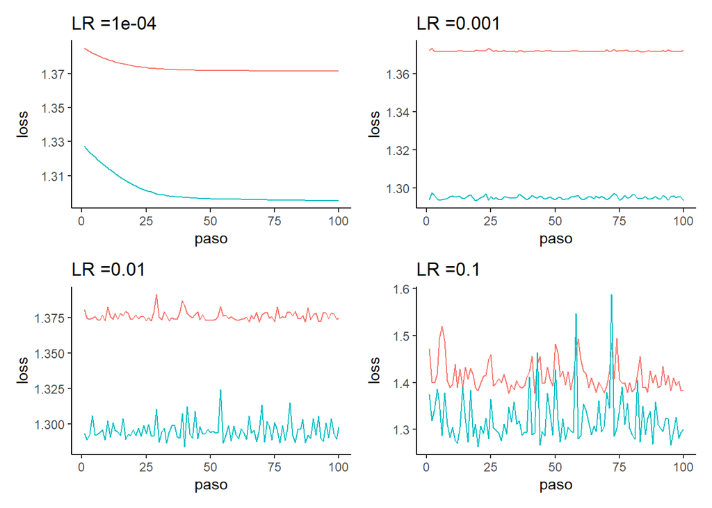

```r
#####

lr<-c(0.0001,0.001,0.01,0.1)
npasos<-100

#####

p<-list()
loss_final<-c()
val_loss_final<-c()

for (k in 1:length(lr)) {

aux<-fun_entrenamiento(modelo1,lr[k],npasos)
n<-dim(aux[1])

p[[k]] <- ggplot(aux,show.legend = FALSE)+
       geom_line(aes(x=paso,y=loss,colour="blue"))+
       geom_line(aes(x=paso,y=val_loss,colour="orange"))+
       labs(title=paste("LR =",lr[k], sep = ""))+
       theme_classic()+
       guides(color = FALSE)

loss_final[k]<-aux$loss[n]
val_loss_final[k]<-aux$val_loss[n]
}

p[[1]] + p[[2]] + p[[3]] + p[[4]]
```

```r
evolucion_lr<-data.frame(lr,loss_final,val_loss_final)
evolucion_lr
```

```
##      lr loss_final val_loss_final
## 1 1e-04   1.371408       1.295326
## 2 1e-03   1.372214       1.293333
## 3 1e-02   1.374585       1.297730
## 4 1e-01   1.384291       1.300342
```

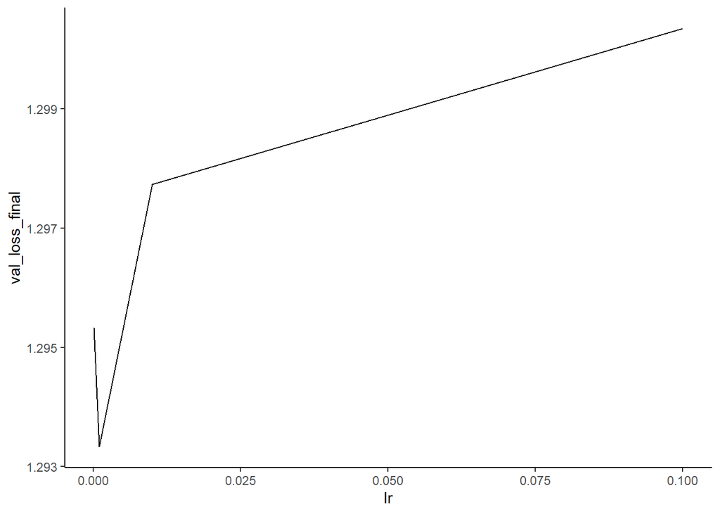

```r
ggplot(evolucion_lr)+
  geom_line(aes(x=lr,y=val_loss_final))+
  theme_classic()
```

Puede ser que haya un problema: Vemos que para distintos LR dentro del rango típico la pérdida no desciende a lo largo del proceso de entrenamiento. Esto se conoce como **under-fitting**, y puede deberse a distintas causas.